```python
%%javascript
MathJax.Hub.Config({
    TeX: { equationNumbers: { autoNumber: "AMS" } }
});
```

```python
import numpy as np
import matplotlib.pyplot as plt
```

# Introduksjon til "endelig differanse"(*)-metoder for Orakler

## (* Finite difference methods)

## Audun Skau Hansen, H2019

# Diskret kalkulus

[figure not shown]

Diskret kalkulus = "opstykket"/numerisk kalkulus.

I diskret kalkulus har vi variabler, funksjoner, operasjoner og modeller som **approksimerer** **kontinuerlige** ("sammenhengende") størrelser i klassisk kalkulus.

| Kontinuerlig | Diskret |
| --- | --- |
| $x$ | $x_i = i\cdot\Delta x$ |
| $f(x)$ | $f_i = f(x_i) = f(i\cdot\Delta x)$ |
| $\frac{d}{dx}$ | $D^+$ |
| $\int$ | $\sum$ |

Med **approksimasjon** menes her at vi gjør en feil. Vi antar ofte at denne er så liten at den kan neglisjeres.

## Diskretisering av variabler

[figure not shown]

I klassisk kalkulus benyttes kontinuerlige variabler:

\begin{equation} x \in \mathbb{R} \end{equation}

En diskretisering innebærer å velge en endelig oppløsning på $\mathbb{R}$, slik at

\begin{equation} x \rightarrow x_i := i\cdot\Delta x, i \in \mathbb{Z} \end{equation}

Dette er ofte første trinn når man klargjør et problem for numerisk løsning.

## Diskretisering av funksjoner

[figure not shown]

Med diskrete variabler, følger det at også funksjoner nå kun er definert i diskrete punkter. Hvor vi i klassisk kalkulus har

\begin{equation} f(x) \end{equation}

har vi nå i steden

\begin{equation} f(x) \rightarrow f_i = f(x_i) = f(i\cdot\Delta x) \end{equation}

## Derivasjon som endelige differanser

I klassisk kalkulus er den deriverte definert som

$$ \frac{d}{dx} f(x) := \lim_{\Delta x \rightarrow 0} \frac{f(x + \Delta x) - f(x)}{\Delta x}$$

I diskret kalkulus er "fremad-differansen" en av flere mulige approksimasjoner på den deriverte

$$ \mathbf{D}^+ f_i := \frac{f_{i+1} - f_i}{\Delta x}$$

## Noen approksimasjoner på den deriverte

| Uttrykk | Navn | Operator |
| --- | --- | --- |
| $\mathbf{D}^+ f(x) := \frac{f(x + \Delta t) - f(x)}{\Delta x}$ | "Fremad-differanse" | $\mathbf{D}^+$ |
| $\mathbf{D} f(x) := \frac{f(x+ \Delta x) - f(x-\Delta x)}{2 \Delta x}$ | "Senterdifferanse" | $\mathbf{D}$ |
| $\mathbf{D}^- f(x) := \frac{f(x) - f(x-\Delta x)}{\Delta x}$ | "Bakoverdifferansen" | $\mathbf{D}^-$ |

# Første ordens differensialligninger

En første ordens (lineær) differensialligning kan uttrykkes:

\begin{equation} f \left( u(x), x \right) = \frac{d}{dx} u(x) . \end{equation}

- Utfordringen er å bestemme den ukjente funksjonen $u(x)$, som skal tilfredsstille relasjonen over.
- Funksjonen $f \left( u(x), x \right)$ er kjent, og involverer både $u$ og $x$.
- Differensialoperatoren for den førstederiverte $\frac{d}{dx}$ inngår på høyre side.

Noen forskjellige notasjoner for førstederiverte:

\begin{equation} \frac{d}{dx} u(x) = u'(x) = \dot{u}(x) \end{equation}

# Diskretisering av differensialligninger

- Både "Fremad Euler" og "Baklengs Euler" er eksempler på såkalte "endelige differanser"-metoder ("finite-difference").
- Generelt sett kan alle slike metoder beskrives som en tretrinns prosedyre:
  - Diskretisering av variabler og funksjoner som inngår i ligningen.
  - Diskretisering av differensialoperatorene.
  - Algebraisk løsning for ukjente.
- Ulike valg av approksimasjoner på differensialoperatorene resulterer i de ulike metodene innenfor "endelige differanser"-hierarkiet.

# Eulers metode / "Fremad Euler" (FE)

I Eulers metode approksimeres den deriverte i en differensialligning med fremoverdifferansen

\begin{equation} f \left( u(x), x \right) = \frac{d}{dx} u(x) \approx \mathbf{D}^+ u(x) = \frac{u(x + \Delta x) - u(x)}{\Delta x} \end{equation}

Metoden kalles *eksplisitt*, fordi vi kan løse de resulterende ligningene slik at verdien $u(x + \Delta x)$ er eksplisitt gitt ved forløpende verdier:

\begin{equation} u(x + \Delta x) = f \left( u(x), x \right) \Delta x + u(x) \end{equation}

Merk imidlertid at vi trenger en initiell verdi $u(0)$ for å komme i gang.

- Slike problemer kalles *initialverdiproblemer*.

# Eksempel på FE for en 1. ordens ODE

Gitt

\begin{equation} \frac{d}{dx} u(x) = -C u(x) , \quad \quad u(x) = u(x_0) e^{-Cx} \end{equation}

1. Diskretisering med FE:

\begin{equation} x \rightarrow x_i := i\cdot\Delta x, i \in \mathbb{Z} \end{equation}\begin{equation} u(x) \rightarrow u_i := u(x_i) \end{equation}\begin{equation} \mathbf{D}^+ u_i = \frac{u_{i+1} - u_i}{\Delta x} = -C u_i \end{equation}

1. Algebraisk løsning for $u_{i+1}$ gir løsningsskjema

\begin{equation} u_{i+1} = -C u_i \Delta x + u_i = \left(1 - C \Delta x \right) u_i \end{equation}

$\rightarrow$ Implementasjon

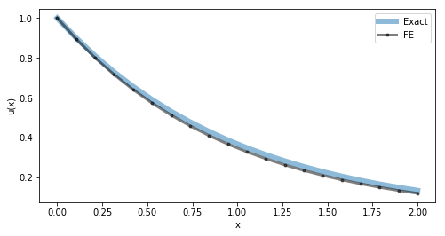

```python
Nsteps = 20 # number of steps
x0, x1 = 0, 2
C  = 1.0 # coefficient

u = np.zeros(Nsteps, dtype = float) #Array to contain solution
u[0] = 1.0 #initial condition

x = np.linspace(x0,x1, Nsteps) #Array containing discretized x_i
dx = x[1]-x[0] # stepsize

for i in np.arange(Nsteps-1):
    u[i+1] = (1 - C*dx)*u[i] # FE step

plt.figure(1, figsize = (8,4)) # Figure to plot solutions
plt.plot(x,u[0]*np.exp(-C*x), "-", linewidth = 6, alpha = .5, label = "Exact")
plt.plot(x,u, ".-", linewidth = 3, alpha = .5, label = "FE", color = (0,0,0))
plt.xlabel("x")
plt.ylabel("u(x)")
plt.legend()
plt.show()
```

## Eulers metode for differensialligninger

Initialverdiproblem:

$$\frac{d}{dt} y(t) = f(y(t), t)$$ $$y(0) = a$$

Følgende fremgangsmåte vil alltid virke i dette kurset, samt i mange andre tilfeller:

1. Diskretiser problemet (variabler, funksjoner). (la $t \rightarrow t_n = n \cdot \Delta t$).
2. Diskretiser differensialoperatoren ($\frac{d}{dt} \rightarrow \mathbf{D}^+$ ).
3. Løs algebraisk for neste funksjonsverdi $f_{n+1} = ...$
4. Skriv en kode som iterativt løser for neste funksjonsverdi.
5. Presenter og fortolk resultatene.

$\rightarrow$ Live kodeeksempel: reaksjonskinetikk med koblede reaksjoner.

# Implisitt Euler / "Baklengs Euler" (BE)

I "Baklengs Euler" approksimeres den deriverte med bakoverdifferansen

\begin{equation} f \left( u(x), x \right) = \frac{d}{dx} u(x) \approx \mathbf{D}^- u(x) = \frac{u(x) - u(x- \Delta x)}{\Delta x} \end{equation}

Metoden kalles *implisitt*, fordi den generelt resulterer i en (gjerne ikke-lineær) relasjon for den ukjente

\begin{equation} u(x) - f \left( u(x), x \right) \Delta x = u(x- \Delta x), \end{equation}

altså en ligning som må løses.

# Eksempel på BE for en 1. ordens ODE

Gitt

\begin{equation} \frac{d}{dx} u(x) = sin( u(x) ) , \quad \quad u(x) = 2 tan^{-1}(e^{x}) \end{equation}

1. Diskretisering med BE:

\begin{equation} x \rightarrow x_i := i\cdot\Delta x, i \in \mathbb{Z} \end{equation}\begin{equation} u(x) \rightarrow u_i := u(x_i) \end{equation}\begin{equation} \mathbf{D}^- u_i = \frac{u_{i} - u_{i-1}}{\Delta x} = sin( u_i ) \end{equation}

1. Algebraisk løsning for $u_{i}$ gir implisitt løsningsskjema

\begin{equation} u_{i} - sin(u_i)\Delta x = u_{i-1} \end{equation}

$\rightarrow$ Hva nå?

# Eksempel på BE for en 1. ordens ODE

Vi skriver om uttrykket for BE:

\begin{equation} u_{i} - sin(u_i)\Delta x - u_{i-1} = 0 \end{equation}

For en gitt $u_{i-1}$ består nå problemet i å bestemme røttene til uttrykket over. Muligens enklere å se dersom vi benytter litt andre navn

\begin{equation} F(x) = x - B sin(x) - A = 0 \quad \quad \frac{d}{dx} F(x) = 1 + B cos(x) \end{equation}

$\rightarrow$ Picarditerasjoner, Newtons metode, linjesøk osv.

```python
def initial_guess1():
    plt.figure(1, figsize = (10,6))

    N = 5
    i = 1
    x = np.linspace(.5,2,N)
    u = np.sin(x)
    plt.plot(x,u, "o-", color = (.4,0,0), linewidth = 5, alpha = .4)
    plt.plot(x[i+1], u[i], "o", color = (0,0,0))
    plt.plot([x[i+1], x[i+1]], [u[i], u[i+1]] , "--", color = (0,0,0), alpha = .5)
    plt.plot([x[i+1], x[i+1]-.05], [u[i+1], u[i+1]-.05], color = (0,0,0), alpha = .5 )
    plt.plot([x[i+1], x[i+1]+.05], [u[i+1], u[i+1]-.05], color = (0,0,0), alpha = .5 )
    plt.text(x[i+1]+.03, 0.85, "Newton Iterations:")
    plt.text(x[i+1]+.03, 0.82," $u_{i,n} = u_{i,n-1} - f(u_{i,n-1}) f'(u_{i,n-1})^{-1}$")
    plt.text(x[i+1]+.03, 0.75, "Initial guess: $u_{i, 0} = u_{i-1}$")

    plt.show()

def initial_guess2():
    plt.figure(1, figsize = (10,6))

    N = 5
    i = 1
    x = np.linspace(.5,2,N)
    u = np.sin(x)
    plt.plot(x,u, "o-", color = (.4,0,0), linewidth = 5, alpha = .4)
    plt.plot(x[i+1], u[i+1]+.1, "o", color = (0,0,0))
    plt.plot([x[i], x[i+1]], [u[i], u[i+1]+.1] , "--", color = (0,0,0), alpha = .5)

    plt.plot([x[i+1], x[i+1]], [u[i+1]+.1, u[i+1]] , "--", color = (0,0,0), alpha = .5)

    plt.plot([x[i+1], x[i+1]-.03], [u[i+1], u[i+1]+.03], color = (0,0,0), alpha = .5 )
    plt.plot([x[i+1], x[i+1]+.03], [u[i+1], u[i+1]+.03], color = (0,0,0), alpha = .5 )
    plt.text(x[i+1]+.03, 1.0, "Newton Iterations:")
    plt.text(x[i+1]+.03, 0.97," $u_{i,n} = u_{i,n-1} - f(u_{i,n-1}) f'(u_{i,n-1})^{-1}$")
    plt.text(x[i+1]+.03, 1.05, "Initial guess: $u_{i, 0} = u_{i-1} + f(u_{i-1}) \Delta x$ (FE)")

    plt.show()
```

```python
Nsteps = 40
x0,x1 = 0, 5.0
u0 = np.pi/2.0

u = np.zeros(Nsteps, dtype = float)
u[0] = u0
x = np.linspace(x0,x1,Nsteps)
dx = x[1]-x[0]


F = lambda u_i, u_i1, dx : u_i - np.sin(u_i)*dx - u_i1
dFdu = lambda u_i, dx : 1 + np.cos(u_i)*dx
J = 0 #count iterations total
for i in np.arange(1,Nsteps):
    # Determine u[i] so that
    #    F(u[i]) = u[i] - sin( u[i] )*dx - u[i-1] = 0
    # Use:   dF/du[i] = 1 + cos(u[i])*dx

    # Newton step
    for j in np.arange(100):
        du = F(u[i], u[i-1], dx)*dFdu(u[i], dx)**-1
        u[i] = u[i] - du
        if np.abs(du)<=1e-8:
            J += j
            break
```

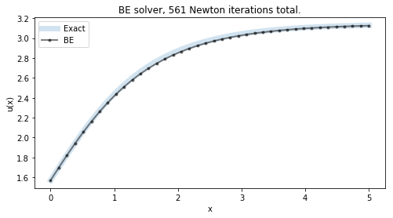

```python
plt.figure(1, figsize = (8,4)) # Figure to plot solutions
plt.title("BE solver, %i Newton iterations total." % J)
plt.plot(x, 2*np.arctan(np.exp(x)), linewidth = 7, alpha = .2, label = "Exact")
plt.plot(x,u, ".-", linewidth = 2, alpha = .5, label = "BE", color = (0,0,0))
plt.xlabel("x")
plt.ylabel("u(x)")
plt.legend()
plt.show()
```

```python
Nsteps = 40
x0,x1 = 0, 5.0
u0 = np.pi/2.0

u = np.zeros(Nsteps, dtype = float)
u[0] = u0
x = np.linspace(x0,x1,Nsteps)
dx = x[1]-x[0]


F = lambda u_i, u_i1, dx : u_i - np.sin(u_i)*dx - u_i1
dFdu = lambda u_i, dx : 1 + np.cos(u_i)*dx
J = 0 #count iterations total
for i in np.arange(1,Nsteps):
    # Determine u[i] so that
    #    F(u[i]) = u[i] - sin( u[i] )*dx - u[i-1] = 0
    # Use:   dF/du[i] = 1 + cos(u[i])*dx

    # Newton step, initial guess:
    u[i] = u[i-1]
    for j in np.arange(100):
        du = F(u[i], u[i-1], dx)*dFdu(u[i], dx)**-1
        u[i] = u[i] - du
        if np.abs(du)<=1e-8:
            J += j
            break
```

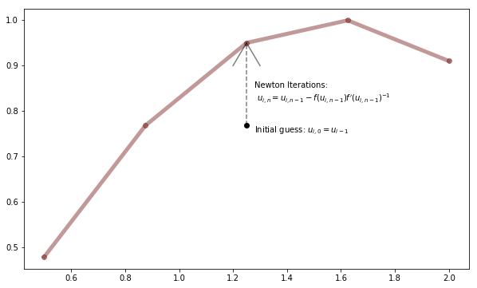

```python
initial_guess1()
```

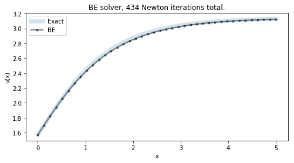

```python
plt.figure(1, figsize = (8,4)) # Figure to plot solutions
plt.title("BE solver, %i Newton iterations total." % J)
plt.plot(x, 2*np.arctan(np.exp(x)), linewidth = 7, alpha = .2, label = "Exact")
plt.plot(x,u, ".-", linewidth = 2, alpha = .5, label = "BE", color = (0,0,0))
plt.xlabel("x")
plt.ylabel("u(x)")
plt.legend()
plt.show()
```

```python
Nsteps = 40
x0,x1 = 0, 5.0
u0 = np.pi/2.0

u = np.zeros(Nsteps, dtype = float)
u[0] = u0
x = np.linspace(x0,x1,Nsteps)
dx = x[1]-x[0]


F = lambda u_i, u_i1, dx : u_i - np.sin(u_i)*dx - u_i1
dFdu = lambda u_i, dx : 1 + np.cos(u_i)*dx
J = 0 #count iterations total
for i in np.arange(1,Nsteps):
    # Determine u[i] so that
    #    F(u[i]) = u[i] - sin( u[i] )*dx - u[i-1] = 0
    # Use:   dF/du[i] = 1 + cos(u[i])*dx

    # Newton step, FE initial guess:
    u[i] = np.sin(u[i-1])*dx + u[i-1]
    for j in np.arange(100):
        du = F(u[i], u[i-1], dx)*dFdu(u[i], dx)**-1
        u[i] = u[i] - du
        if np.abs(du)<=1e-8:
            J += j
            break
```

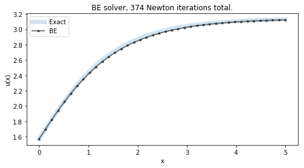

```python
plt.figure(1, figsize = (8,4)) # Figure to plot solutions
plt.title("BE solver, %i Newton iterations total." % J)
plt.plot(x, 2*np.arctan(np.exp(x)), linewidth = 7, alpha = .2, label = "Exact")
plt.plot(x,u, ".-", linewidth = 2, alpha = .5, label = "BE", color = (0,0,0))
plt.xlabel("x")
plt.ylabel("u(x)")
plt.legend()
plt.show()
```

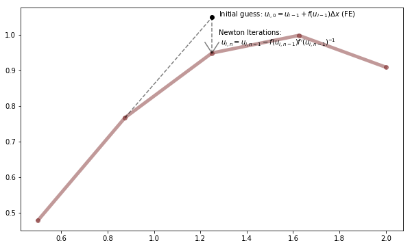

```python
initial_guess2()
```

## Nyttig info

- I introduksjonskursene på 1000-nivå benyttes sjeldent diffligninger av høyere orden enn 1.
- Bruken av $\mathbf{D}$-operatorene gjør det enkelt å generalisere til FE og BE på både høyere orden, ikke-lineære og partielle ligninger.
- Dette en styrke i FD-metoder.

Andre ordens ODE:

\begin{equation} \frac{d^2}{dx^2} u(x) = f \left( u(x), x \right) \end{equation}

Approksimasjon (FE):

\begin{equation} \frac{d^2}{dx^2} u(x) \approx \mathbf{D}^+ \mathbf{D}^+ u(x) = \mathbf{D}^+ \left( \frac{u(x + \Delta x) - u(x)}{\Delta x} \right) = \frac{1}{\Delta x^2} \left(u(x + 2\Delta x) - 2 u(x+ \Delta x) + u(x) \right) \end{equation}

Fordi

\begin{equation} \mathbf{D}^+ \frac{u(x + \Delta x)}{\Delta x} = \frac{u(x + 2\Delta x) - u(x + \Delta x)}{\Delta x} \end{equation}

Partiell differensialligning (PDE):

\begin{equation} \frac{d^2}{dt^2} u(x,t) = - C \frac{d^2}{dx^2} u(x,t) \end{equation}

Approksimasjon (FE)

\begin{equation} \mathbf{D}_t^+ \mathbf{D}_t^+ u(x,t) = - C \mathbf{D}_x^+ \mathbf{D}_x^+ u(x,t) \end{equation}

$\rightarrow$ Løs algebraisk for ukjente.

```python
!jupyter nbconvert FDSchemes_Intro.ipynb --to slides --post serve
```

[output not shown]